# Estudios de Informática, Multimedia y Telecomunicaciones

# TFM-Density algorithms applied to SDSS

Carlos Toro Peñas

2025-12-15

# 1 The clustering problem on galaxy dataset

Rather than pursuing a traditional unsupervised clustering optimization—such as variance maximization via the **Elbow Method**—this work evaluates the efficacy of **density-based clustering algorithms** in replicating a physically motivated **halo-based group finder**.

We aim to identify the optimal hyperparameter configurations that allow these algorithms to recover the underlying **dark matter halo membership** of galaxies, effectively using the halo-based catalog as a benchmark for physical validity.

# 2 Loading data files

## 2.1 Galaxy catalog for SDSS

```
## 'data.frame':    639359 obs. of  9 variables:
##  $ GAL_ID  : int  750 751 752 994 1010 1030 1038 1042 1049 1050 ...
##  $ ra      : num  38 38.4 38.4 54.5 54.5 ...
##  $ dec     : num  0.224 0.212 0.211 0.573 0.579 ...
##  $ x       : num  0.042 0.0417 0.0419 0.0779 0.0726 ...
##  $ y       : num  0.0329 0.033 0.0331 0.1091 0.1019 ...
##  $ z       : num  0.000209 0.000197 0.000196 0.00134 0.001264 ...
##  $ redshift: num  0.054 0.0538 0.0541 0.1385 0.129 ...
##  $ dist    : num  0.0534 0.0532 0.0534 0.1341 0.1251 ...
##  $ GROUP_ID: int  68171 23701 23701 68172 68173 68174 23702 23702 68175 68176 ...
```

# 3 Generic functions for assessments

## 3.1 Functions to asses outcomes

To assess the outcomes we will based our analysis on tree basic concepts:

**Purity(P)**: measure of output-cluster: proportion of members coming exclusively from a single true group, providing confidence that the algorithm correctly groups members together. A high purity rate indicates the algorithm’s effectiveness in identifying true groups.

**Completeness (C)**: measure of an output-cluster: proportion of data true-group elements included in an output-cluster. A cluster is “complete” if contains all points of the original true group.

**Recovery (R)**: measure of an output-cluster (much more restrictive): proportion of output-clusters which are both pure and complete. For this study we consider an output-cluster to be pure if P>=0.66 (at least 2/3 of elements of an output-cluster belong to a single group). An original cluster is complete if C>=0.5 (at least half data belong to an original true group).

Some other stats are:

**total_in_group:** number of elements in a given group.

**total_in_cluster:** number of elements in a given output-cluster.

**total_in_cluster_group:** number of elements in a given output-cluster belonging to a majority-group.

**undetected_groups**: original groups not detected as majority-group in output-clusters.

**detected_groups**: original groups detected as majority-group in output-clusters.

Following code is aimed to asses the outcomes obtained with from an given output-cluster:

```r
sys.source(sprintf("%s\\assess.r", includes_folder), envir = knitr::knit_global())
```

Following code is intended to calculate stats

```r
sys.source(sprintf("%s\\calculate_stats.r", includes_folder), envir = knitr::knit_global())
```

We generated some functions to help us visualize the results graphically:

```r
sys.source(sprintf("%s\\plotting_functions.r", includes_folder),  envir = knitr::knit_global())
```

Last file to include content function to compute slos distance:

```r
sys.source(sprintf("%s\\slos.r", includes_folder),  envir = knitr::knit_global())
```

# 4 Data Preprocessing

## 4.1 Descriptive analysis **and visualization**

There is an initial preprocessing of data-file in order to obtain proper distances and cartesian coordinates x,y,z, by now it is omitted here.

Take a sample bounded by minPts = 5 and RA and DEC:

$$RA \in [90, 150] h,\, DEC \in [15, 25]
º,\, \,and\,\, z \lt max\_redshift$$

Then we take the initial values and take a look at the remaining distribution:

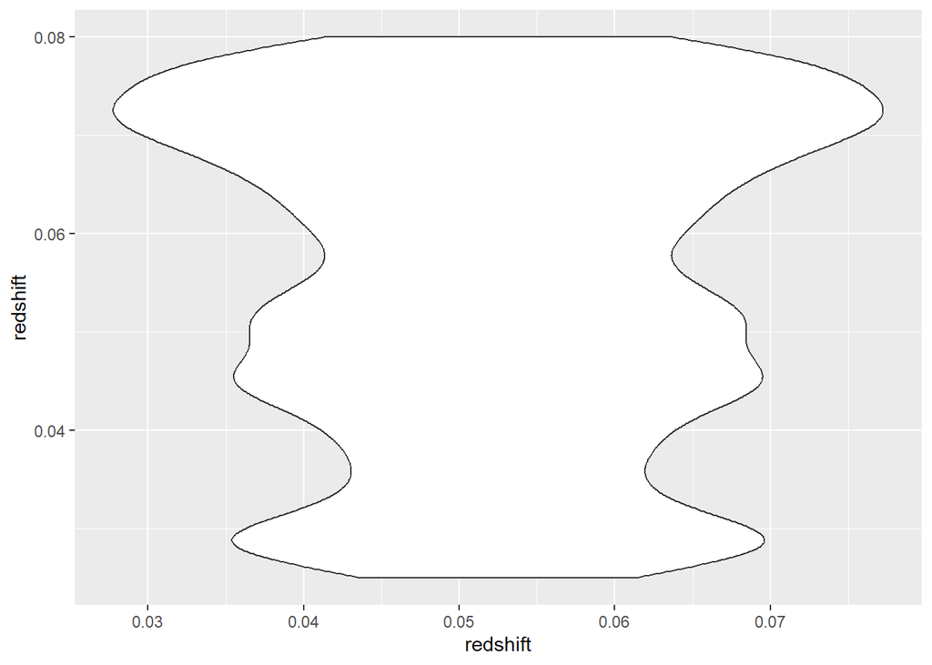

```r
SLOS <- 0.4 #Here the slos is fixed beforehand
min_members <- 5

ra_lim_inf <- 90
ra_lim_sup <- 150

dec_lim_inf <- 15
dec_lim_sup <-  25

max_redshift <- 0.08
min_redshift <- 0.025

# Take a sample using boundaries
mm <- dt[ dt$ra<= ra_lim_sup & dt$ra>=ra_lim_inf &
            dt$dec>= dec_lim_inf & dt$dec<=dec_lim_sup &
            dt$redshift< max_redshift & dt$redshift> min_redshift,]


# mm is an object containing both groups and galaxy identification
ggplot(mm, aes(x=redshift, y=redshift))+geom_violin()
```

```r
dim(mm)
```

```
## [1] 7229    9
```

Select groups with more than min_members members queries:

```r
h<-sqldf("select
            count(GAL_ID) as members,
            GROUP_ID
          from
            mm
          group by
            GROUP_ID
          order by
            members desc")
mm5<-sqldf(sprintf("
    SELECT
        mm.GAL_ID,
        mm.x,
        mm.y,
        mm.z,
        mm.GROUP_ID,
        mm.redshift,
        mm.dist
      FROM
        mm as mm, h
      where
          mm.GROUP_ID=h.GROUP_ID and
          h.members >= %s"
      , min_members))
```

Then use it to find the target data:

```r
true_groups <- length(unique(mm5$GROUP_ID))
number_non_isolated_galaxies <- dim(mm5)[1]
number_isolated_galaxies <- dim(mm)[1] - dim(mm5)[1]
print(
  sprintf('Number of galaxies in groups with more than %s elements %s out of %s, aprox %s percent',
          min_members,
          number_non_isolated_galaxies,
          dim(mm)[1], format(number_non_isolated_galaxies * 100
                                /dim(mm)[1], digits=4)))
```

```
## [1] "Number of galaxies in groups with more than 5 elements 1237 out of 7229, aprox 17.11 percent"
```

```r
print(sprintf("Number of groups with more than %s members: %s",
              min_members,
              true_groups))
```

```
## [1] "Number of groups with more than 5 members: 95"
```

We take a look at the groups with more than min_members:

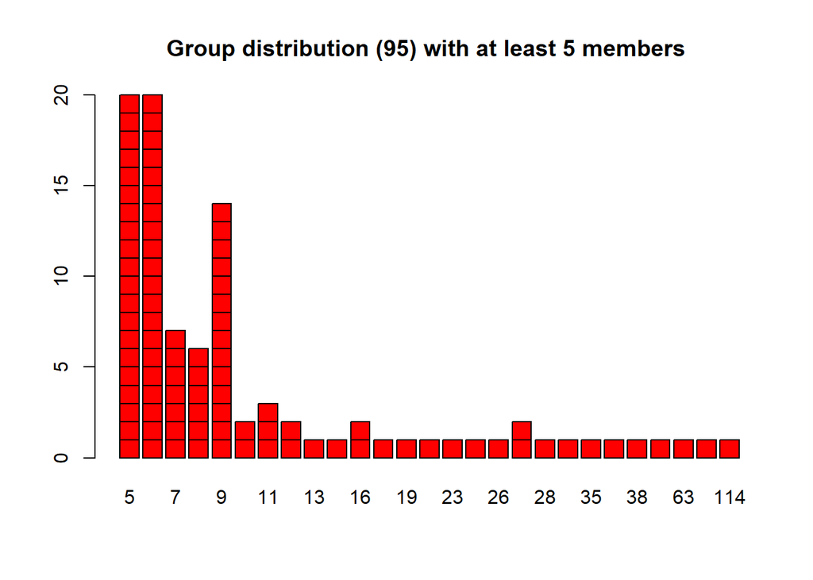

```r
hhh<- h[h$members>=min_members, ]
ttable <- table(hhh$GROUP_ID, hhh$members)
barplot(ttable, col=('red'),
        main=sprintf("Group distribution (%s) with at least %s members ",
                     true_groups,
                     min_members))
```

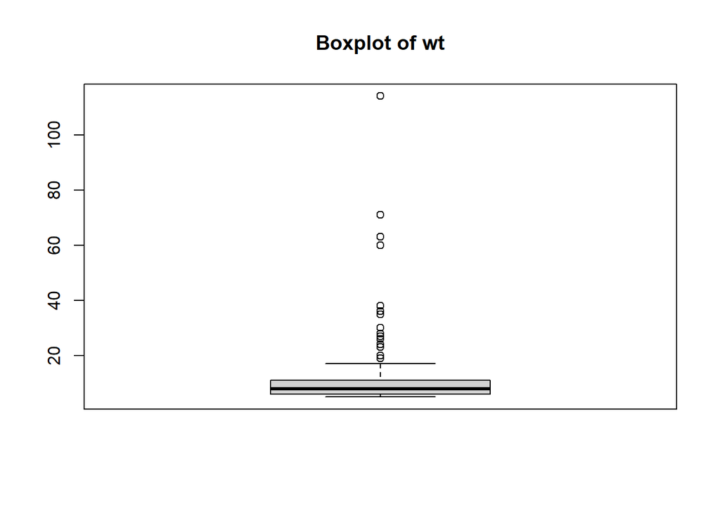

```r
boxplot(hhh$members, main="Boxplot of wt")
```

Lets take a look at the complete target sample:

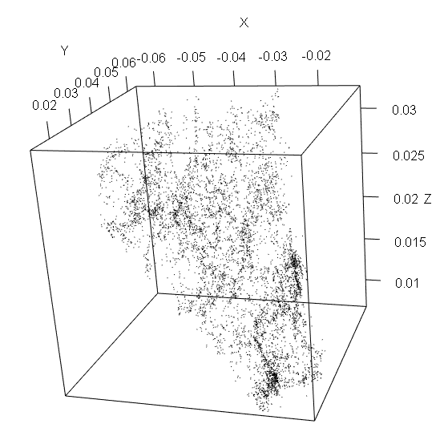

```r
plot3d(mm$x, mm$y, mm$z, col = 'black',
       size = 1, xlab = "X", ylab = "Y", zlab = "Z")
```

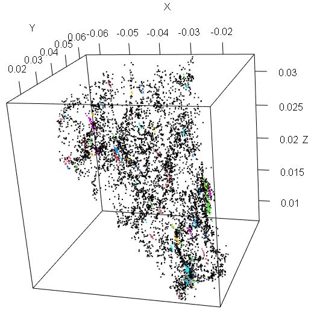

```r
aa <- sqldf("select
          GAL_ID,
          x,
          y,
          z,
            case
              when group_id IN (Select GROUP_ID from mm5) then group_id
          else 0
            end as group_id,
          redshift,
          dist
      from
            mm")

plot3d(aa$x, aa$y, aa$z, col = aa$group_id+1,
       size = 2, xlab = "X", ylab = "Y", zlab = "Z")
```

And the groups with more than min_members:

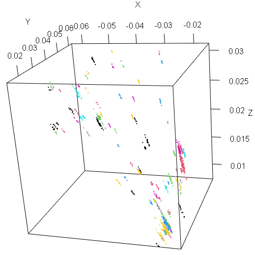

```r
plot3d(mm5$x, mm5$y, mm5$z, col = mm5$GROUP_ID,
       size = 2, xlab = "X", ylab = "Y", zlab = "Z")
```

# 5 Raw data processing

We will process the data without any kind of scale or normalization.

## 5.1 OPTICS

Optics clustering:

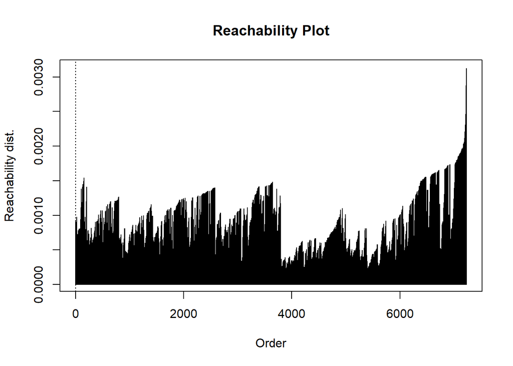

```r
points<- mm[,c('x', 'y', 'z')]

#clustering
res <- optics(points, minPts = min_members)
plot(res)
```

In the previous plot we can see how OPTICS modeling valleys (clusters) and the peaks (cluster-separation).

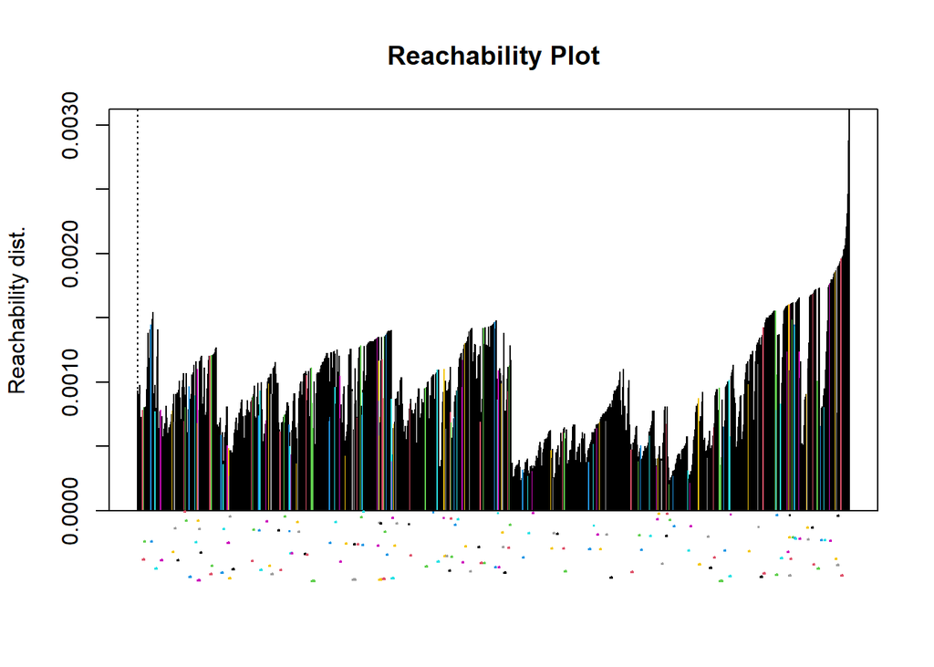

```r
optics <- extractXi(res, xi=0.15)
plot(optics)
```

### 5.1.1 Output-clusters visualization

Take a plot of the clustering obtained:

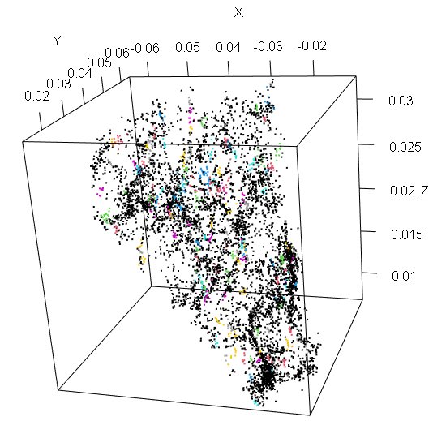

```r
plot3D_cluster(optics, mm)
```

Stats with different values

```r
mm$cluster_id <- as.numeric(optics$cluster)
mm5 <- get_elements_in_m5_groups(mm)
all <- execute_stats(mm, optics)
print_stats(all)
```

```
## [1] "Mean purity 0.424601883018884"
## [1] "Mean completness 0.851048303520381"
## [1] "Sum. recovery  0.0800323362974939"
## [1] "Undetected groups 53 out of 95"
## [1] "Detected pure and complete groups 13  out of 95"
## [1] "Detected real groups  51  out of 95"
```

This algorithm do not offer good results in cluster detection.

## 5.2 DBSCAN

We can directly apply extractDBSCAN on the OPTICS model.

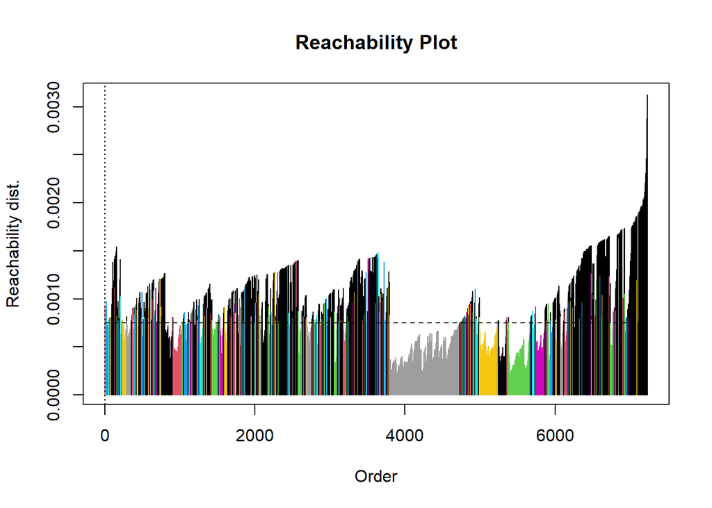

```r
blo_scan <- extractDBSCAN(res, eps_cl = 0.00075)
mm$cluster_id <- blo_scan$cluster
mm5 <- get_elements_in_m5_groups(mm)
plot(blo_scan)
```

### 5.2.1 Output-clusters visualization

We have, on one hand all groups with more than min_members members (made up by a reduced amount of galaxies from catalog)

in the other hand the output-clusters from DBSCAN:

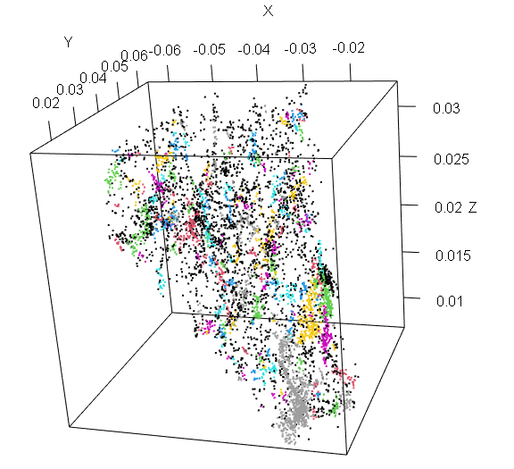

```r
plot3D_cluster(blo_scan, points)
```

```r
all <- execute_stats(mm, blo_scan)
head(all, 5)
```

```
##   cluster_id group_id total_in_group total_in_cluster total_in_cluster_group
## 1          1   229735              1                7                      1
## 2          3     6818              5               27                      5
## 3          9    36542              2                5                      2
## 4          8      667              4                4                      3
## 5        184      442             30              107                     29
##      purity  completn spurious bad_class is_pur is_comp   recovery is_real
## 1 0.1428571 1.0000000        6         0      0       1 0.00000000       0
## 2 0.1851852 1.0000000       22         0      0       1 0.00000000       1
## 3 0.4000000 1.0000000        3         0      0       1 0.00000000       0
## 4 0.7500000 0.7500000        1         1      1       1 0.00323363       0
## 5 0.2710280 0.9666667       78         1      0       1 0.00000000       1
```

```r
print_stats(all)
```

```
## [1] "Mean purity 0.331716556063967"
## [1] "Mean completness 0.987335200247408"
## [1] "Sum. recovery  0.0695230396119644"
## [1] "Undetected groups 48 out of 95"
## [1] "Detected pure and complete groups 13  out of 95"
## [1] "Detected real groups  47  out of 95"
```

We can now test over different values in order to obtain optimal eps_cl hyper-parameter:

```r
#It is easy to transform onto a function which admits a sequence and a res set.
eps_sequence_test <- seq(0.0001, 0.0007, 0.0002)
x_stats <- extract_stats_dbscan(eps_sequence_test, res)
```

```
## [1] "Extracting DBSCAN stats for epsI=1e-04"
## [1] "Extracting DBSCAN stats for epsI=3e-04"
## [1] "Extracting DBSCAN stats for epsI=5e-04"
## [1] "Extracting DBSCAN stats for epsI=7e-04"
```

Show the results obtained:

```r
print_global_stats(x_stats, eps_sequence_test)
```

```
## [1] "############### DATA FOR eps values ############"
## [1] "#############################################"
## [1] ""
## [1] ""
## [1] "Completeness 0.104655712050078 0.587461969390989 0.900311864752456 0.976725345423947"
## [1] "Purity 1 0.780112362242708 0.487567823777937 0.363354522087879"
## [1] "Groups 2 89 242 256"
## [1] "Clusters 2 117 245 256"
## [1] "EPS 1e-04 3e-04 5e-04 7e-04"
## [1] "True Groups 95"
## [1] "Und. Groups 93 45 32 43"
## [1] "Complete gr.: 0 67 233 255"
## [1] "Pure gr.: 2 83 59 30"
## [1] "P.+ C. gr.: 0 38 47 30"
## [1] "Real groups: 2 78 66 52"
## [1] "Fr: 0 0.322033898305085 0.191056910569106 0.116731517509728"
## [1] "Fp: 0.666666666666667 0.703389830508475 0.239837398373984 0.116731517509728"
## [1] "FC: 0 0.567796610169492 0.947154471544715 0.992217898832685"
## [1] "Spurious: 0 1.53846153846154 6.43673469387755 13.1328125"
## [1] "Bad class: 48.5 12.6324786324786 1.11836734693878 0.3828125"
## [1] "Recovery: 0 0.234438156831043 0.265157639450283 0.0994341147938561"
```

Lets get a plots for completeness and purity:

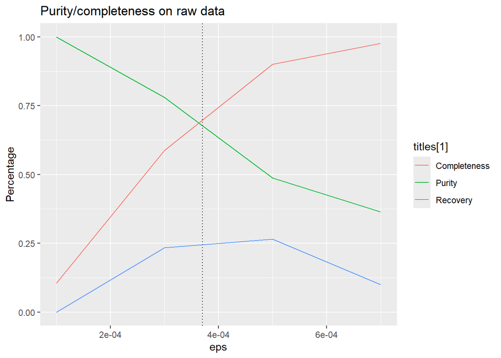

```r
seleced_eps<- 0.00037
plot_purity_completeness(
  eps_sequence_test,
  x_stats$purity_list,
  x_stats$completeness_list,
  x_stats$recovery,
  c('Purity', 'Completeness', 'Recovery'),
  "Purity/completeness on raw data",
  seleced_eps, 'eps', 'Percentage'
)
```

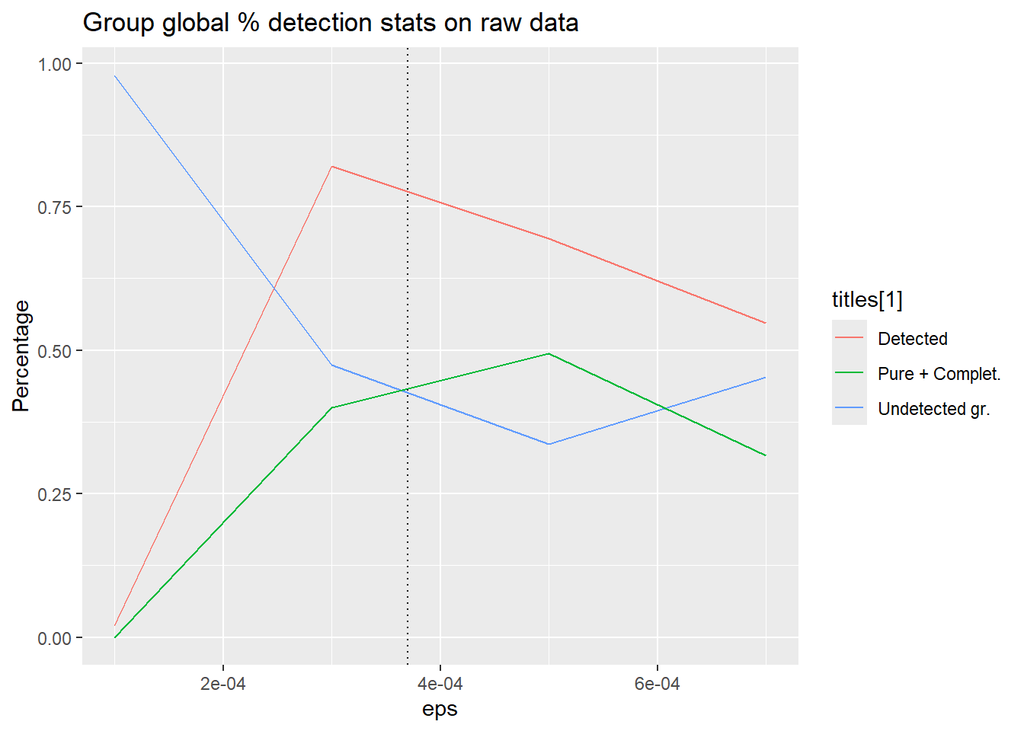

```r
plot_purity_completeness(
  eps_sequence_test,
  x_stats$real_list/true_groups,
  x_stats$und_gr/true_groups,
  x_stats$pure_complet/true_groups,
  c('Detected', 'Undetected gr.', 'Pure + Complet.'),
  "Group global % detection stats on raw data",
  seleced_eps , 'eps', 'Percentage'
)
```

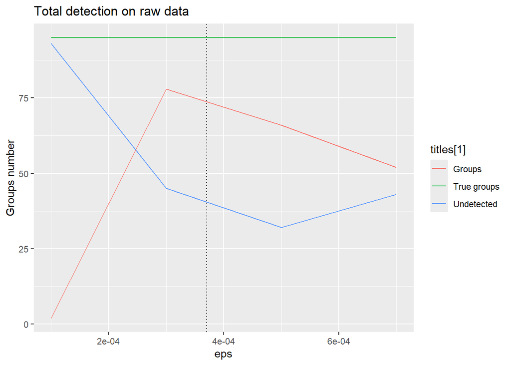

```r
plot_purity_completeness(
  eps_sequence_test,
  x_stats$und_gr,
  x_stats$real_list,
  true_groups - 0,
  c('Undetected', 'Groups', 'True groups'),
  "Total detection on raw data",
   seleced_eps , 'eps', 'Groups number'
)
```

# 6 HDBSCAN data processing

As said from theory, HDBSCAN does not generate a great model because it ability to detect clusters in sparse areas. It cause detect noise as clusters.

```r
cl <- hdbscan(points, minPts = 5)
length(unique( cl$cluster))
```

```
## [1] 376
```

## 6.1 Output-clusters visualization

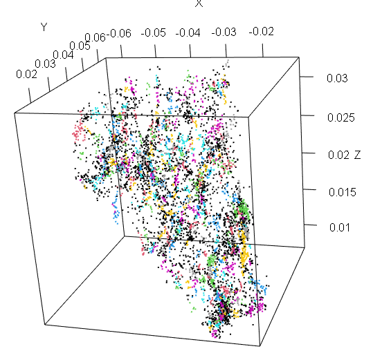

```r
plot3D_cluster(cl, mm)
```

HDBSCAN do not work pretty well because it detects cluster in sparser areas which gives as a result cluster detection on noise regions.

# 7 Density Peaks Clustering(DPC )

Alex Rodriguez and Alessandro Laio (2014).

https://github.com/thomasp85/densityClust

By making this way it appears some clusters:

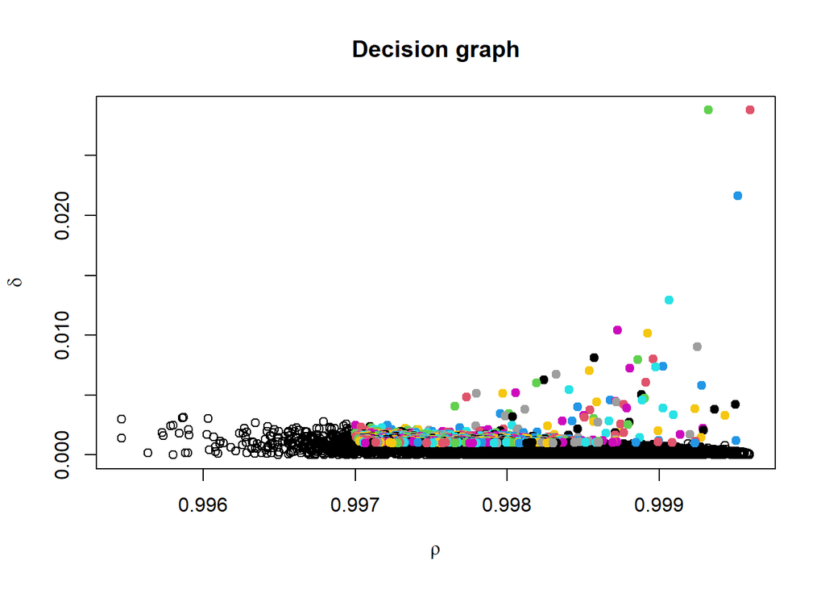

```r
galaxyDens <- densityClust(points)
galaxyClusters <- findClusters(galaxyDens, rho=0.997, delta=0.001)
plot(galaxyClusters)
```

```r
# do not use this takes a lot!!:
#plotMDS(galaxyClusters)

mm$cluster_id <- galaxyClusters$cluster
```

```r
all <- execute_stats(mm, galaxyClusters)
print_stats(all)
```

```
## [1] "Mean purity 0.5961860903516"
## [1] "Mean completness 0.989302040312048"
## [1] "Sum. recovery  0.325788197251415"
## [1] "Undetected groups 36 out of 95"
## [1] "Detected pure and complete groups 13  out of 95"
## [1] "Detected real groups  65  out of 95"
```

DPC is analogous to HDBCAN: the model do not fit well for the same reason: detecting clusters in noise regions.

May be DPC is not good in finding cluster but it can be useful in finding the centers by finding the peaks of density, as we show bellow:

```r
galaxyClusters <- findClusters(galaxyDens, rho=0.9985, delta=0.00084)
peaks <- mm[galaxyClusters$peaks,]
print(sprintf("DPC detected %s out of %s clusters", length(unique(peaks$GROUP_ID)), true_groups))
```

```
## [1] "DPC detected 113 out of 95 clusters"
```

In fact we can create a heat-map for $\rho$ and $\delta$ hyper-parameters:

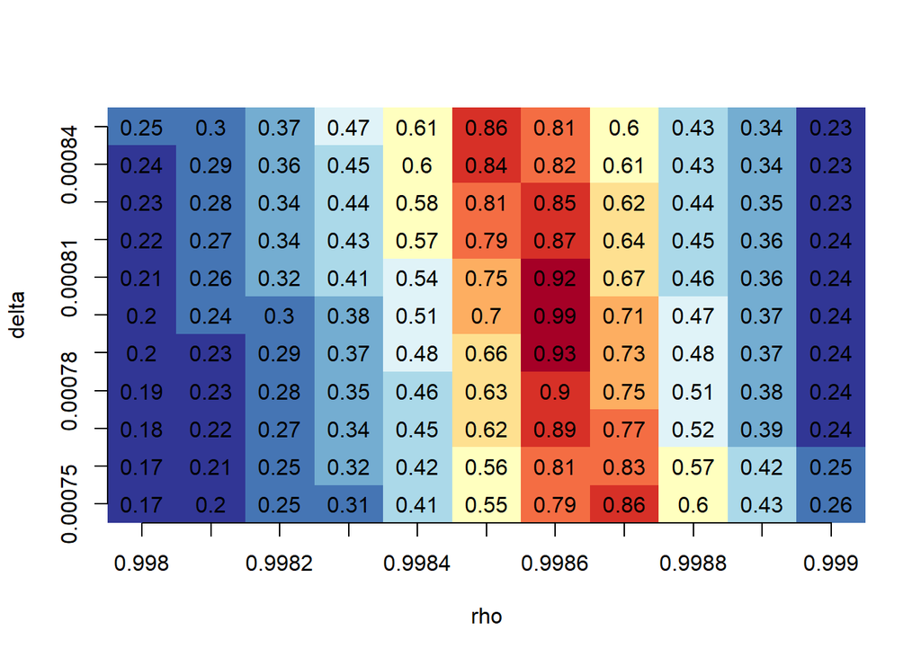

```r
rhos <- seq(0.9980, 0.999, 0.0001)
deltas <- seq(0.00075, 0.00085, 0.00001)

ll <-  length(deltas)
j<-1
i<-ll
matrix_data=matrix(ncol=length(rhos), nrow = length(deltas))
for (rho in rhos){
    for (delta in deltas){
        galaxyClusters <- findClusters(galaxyDens, rho=rho, delta=delta)
        peaks <- mm[galaxyClusters$peaks,]
        l <- length(unique(peaks$GROUP_ID))
        #print(min(l/true_groups, true_groups/l))
        matrix_data[i, j] <- min(l/true_groups, true_groups/l)
        i <- i-1
    }
    j <- j+1
    i<-ll
}


custom_heatmap(matrix_data, deltas, rhos, xTitle = "rho", yTitle = "delta", numColors = 11)
```

## 7.1 Output-clusters visualization

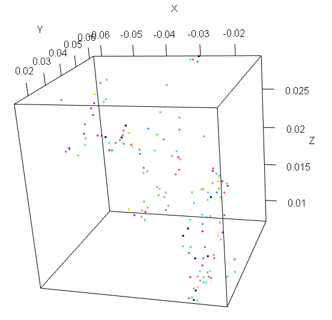

```r
galaxyClusters <- findClusters(galaxyDens, rho=0.9985, delta=0.0008)
peaks <- mm[galaxyClusters$peaks,]
plot3d(peaks$x, peaks$y, peaks$z, col = peaks$GROUP_ID+1,
         size = 3, xlab = "X", ylab = "Y", zlab = "Z")
```

# 8 Normalized data processing

We will perform a scale of data:

```r
points_scaled <- scale(points)
ress <- optics(points_scaled, minPts = min_members)
#optimal value obtained
blo_scans <- extractDBSCAN(ress, eps_cl = 0.025)
mm$cluster_id <- blo_scans$cluster
mm5 <- get_elements_in_m5_groups(mm)
```

Again we can do the same for scaled data:

```r
eps_sequence_test <- seq(0.025, 0.04, 0.005)
x_stats <- extract_stats_dbscan(eps_sequence_test, ress)
```

```
## [1] "Extracting DBSCAN stats for epsI=0.025"
## [1] "Extracting DBSCAN stats for epsI=0.03"
## [1] "Extracting DBSCAN stats for epsI=0.035"
## [1] "Extracting DBSCAN stats for epsI=0.04"
```

```r
print_global_stats(x_stats, eps_sequence_test)
```

```
## [1] "############### DATA FOR eps values ############"
## [1] "#############################################"
## [1] ""
## [1] ""
## [1] "Completeness 0.473561897732598 0.616829208904767 0.692938249329233 0.797341370519604"
## [1] "Purity 0.850963117342428 0.763104516529589 0.692646481028888 0.606210510933657"
## [1] "Groups 61 99 123 160"
## [1] "Clusters 87 122 143 174"
## [1] "EPS 0.025 0.03 0.035 0.04"
## [1] "True Groups 95"
## [1] "Und. Groups 56 43 33 31"
## [1] "Complete gr.: 40 75 104 145"
## [1] "Pure gr.: 69 84 83 73"
## [1] "P.+ C. gr.: 24 39 49 51"
## [1] "Real groups: 65 75 82 78"
## [1] "Fr: 0.272727272727273 0.317073170731707 0.340277777777778 0.291428571428571"
## [1] "Fp: 0.784090909090909 0.682926829268293 0.576388888888889 0.417142857142857"
## [1] "FC: 0.454545454545455 0.609756097560976 0.722222222222222 0.828571428571429"
## [1] "Spurious: 0.735632183908046 1.40983606557377 2.46853146853147 3.82183908045977"
## [1] "Bad class: 20.4022988505747 10.7131147540984 8.09090909090909 4.49425287356322"
## [1] "Recovery: 0.144704931285368 0.398544866612773 0.576394502829426 0.473726758286176"
```

Results look sligthly better when all variables are scaled to a mean=0, sd=1. The optimal value of eps gives more than 69% for both purity and completeness.

The same plots before

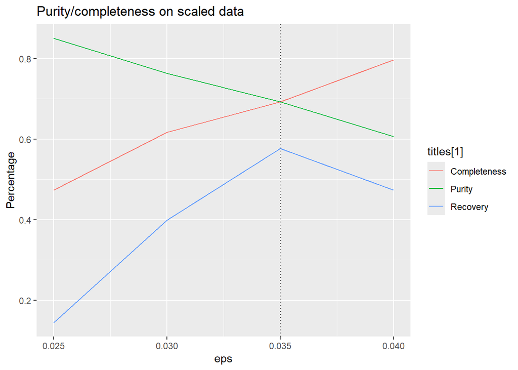

```r
seleced_eps <- 0.035

plot_purity_completeness(
  eps_sequence_test,
  x_stats$purity_list,
  x_stats$completeness_list,
  x_stats$recovery,
  c('Purity', 'Completeness', 'Recovery'),
  "Purity/completeness on scaled data",
  seleced_eps, 'eps', 'Percentage'
)
```

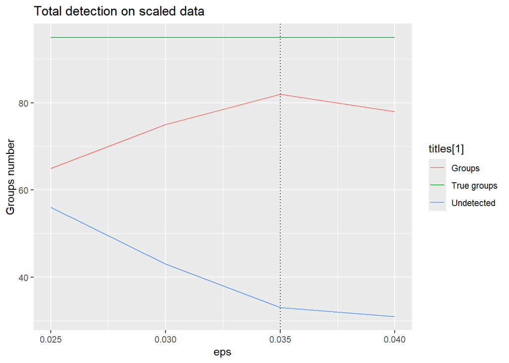

```r
plot_purity_completeness(
  eps_sequence_test,
  x_stats$und_gr,
  x_stats$real_list,
  true_groups - 0,
  c('Undetected', 'Groups', 'True groups'),
  "Total detection on scaled data",
   seleced_eps , 'eps', 'Groups number'
)
```

## 8.1 Elbow method

We have selected that minPts = min_members, which is a reasonable value for interpreting a group / clustering.

From the DBSCAN theory we can use the elbow on:

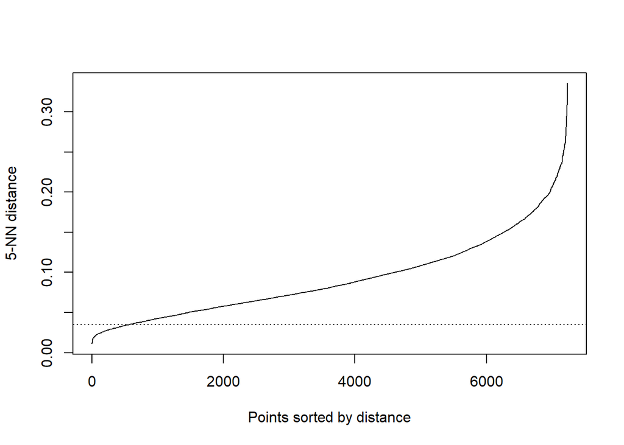

```r
kNNdistplot(x = points_scaled, k = min_members)
abline(h = seleced_eps, lty = 3)
```

How reader can see, the “elbow method” does not apply here, the reason for this is that elbow method try to optimize variances in clusters. Rather, we are trying to detect virialized galaxy groups, but algorithms are not intrinsically designed to account for the specific density profiles of dark matter halos.

## 8.2 Detected/Undetected original groups

The element whose groups were not detected are:

```r
blo_scans <- extractDBSCAN(ress, eps_cl = seleced_eps)
mm$cluster_id <- blo_scans$cluster

all <- execute_stats(mm, blo_scans)

undetected <- get_elements_not_in_groups(mm5, all)
detected <- get_elements_in_groups(mm, all)

print(sprintf('Undetected groups: %s', length(unique(undetected$GROUP_ID))))
```

```
## [1] "Undetected groups: 33"
```

```r
print(sprintf('Detected groups: %s', length(unique(detected$GROUP_ID))))
```

```
## [1] "Detected groups: 123"
```

Plot detected groups

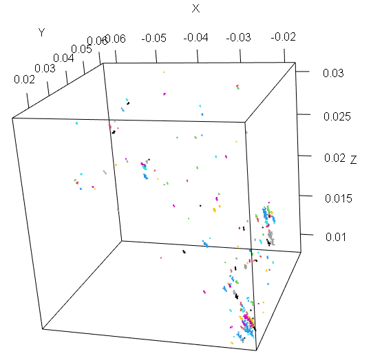

```r
plot3d(detected$x, detected$y, detected$z,
       col = detected$cluster_id +1, size = 2,
       xlab = "X", ylab = "Y", zlab = "Z")
```

Plot undetected groups

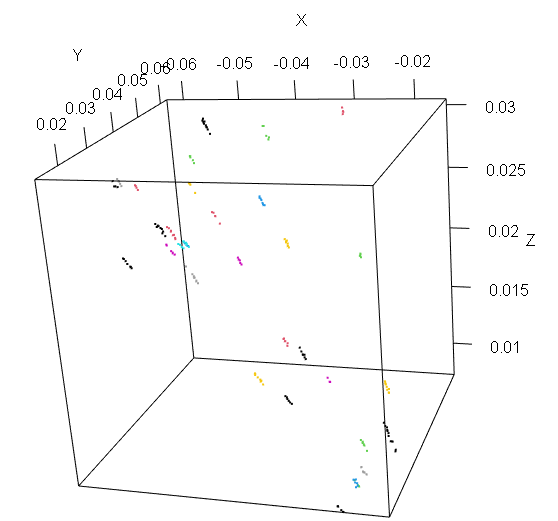

```r
plot3d(undetected$x, undetected$y, undetected$z,
       col = undetected$GROUP_ID, size = 2,
       xlab = "X", ylab = "Y", zlab = "Z")
```

# 9 s-Distances (SLos application)

We will use the code to calculate the s-distance, which consists in make a elongation along the line of sight.

## 9.1 sDistances Matrix Calculation

We can calculate distance matrix to apply OPTICS to this new metric, executing following code may take a long time:sDistances Matrix Calculation

```r
SLOS <- 0
a<- mm[,c('x', 'y', 'z', 'dist', 'redshift')]
distance_matrix <- get_matrix_of_distances(a)
#Following code last a long time to execute
dist_object <- as.dist(distance_matrix)
```

## 9.2 OPTICS

Apply OPTICS algorithm and then obtain a reachability plot:

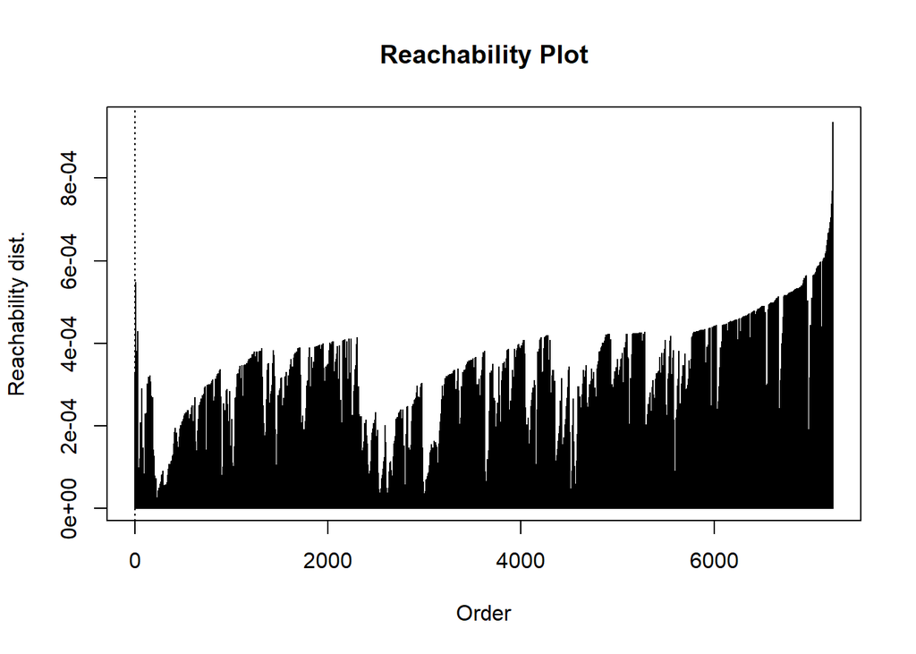

```r
sres <- optics(dist_object, minPts = min_members)
plot(sres)
```

## 9.3 DBSCAN:

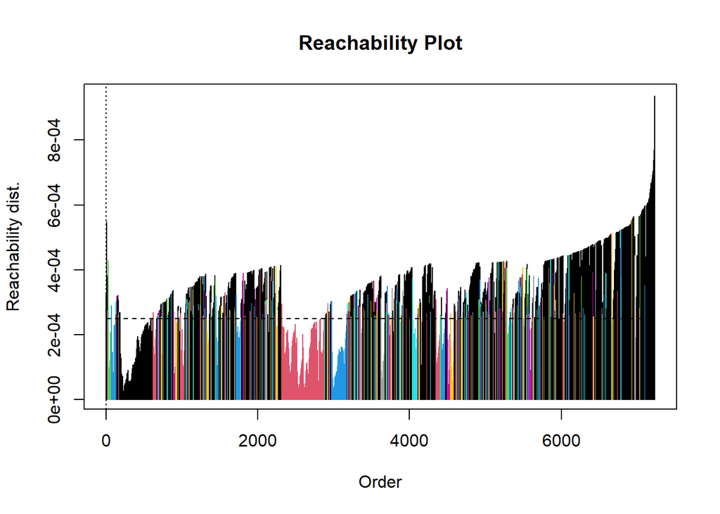

```r
sblo_scan <- extractDBSCAN(sres, eps_cl = 0.00025)
mm$cluster_id <- sblo_scan$cluster
#mm5 <- get_elements_in_groups(mm)
plot(sblo_scan)
```

We obtain a notable improvement:

```r
sall <- execute_stats(mm, sblo_scan)
print_stats(sall)
```

```
## [1] "Mean purity 0.431980396663884"
## [1] "Mean completness 0.99406555643669"
## [1] "Sum. recovery  0.29749393694422"
## [1] "Undetected groups 30 out of 95"
## [1] "Detected pure and complete groups 13  out of 95"
## [1] "Detected real groups  65  out of 95"
```

Test several hyper-parameters:

```r
#optimal value found at 0.00015
#eps_sequence_test <- seq(0.000085, 0.00020, 0.00005)
eps_sequence_test <- seq(0.00005, 0.00025, 0.00005)
sx_stats <- extract_stats_dbscan(eps_sequence_test, sres)
```

```
## [1] "Extracting DBSCAN stats for epsI=5e-05"
## [1] "Extracting DBSCAN stats for epsI=1e-04"
## [1] "Extracting DBSCAN stats for epsI=0.00015"
## [1] "Extracting DBSCAN stats for epsI=2e-04"
## [1] "Extracting DBSCAN stats for epsI=0.00025"
```

```r
print_global_stats(sx_stats, eps_sequence_test)
```

```
## [1] "############### DATA FOR eps values ############"
## [1] "#############################################"
## [1] ""
## [1] ""
## [1] "Completeness 0.568991669563859 0.820834474427593 0.953146668561144 0.975637190444883 0.99406555643669"
## [1] "Purity 0.86246825950707 0.719006683502973 0.597271129268692 0.513046960218581 0.431980396663884"
## [1] "Groups 56 137 191 260 291"
## [1] "Clusters 64 144 191 260 291"
## [1] "EPS 5e-05 1e-04 0.00015 2e-04 0.00025"
## [1] "True Groups 95"
## [1] "Und. Groups 51 16 13 18 30"
## [1] "Complete gr.: 40 131 189 259 291"
## [1] "Pure gr.: 53 84 79 77 55"
## [1] "P.+ C. gr.: 30 74 77 77 55"
## [1] "Real groups: 52 86 82 77 65"
## [1] "Fr: 0.461538461538462 0.510344827586207 0.401041666666667 0.295019157088123 0.188356164383562"
## [1] "Fp: 0.815384615384615 0.579310344827586 0.411458333333333 0.295019157088123 0.188356164383562"
## [1] "FC: 0.615384615384615 0.903448275862069 0.984375 0.992337164750958 0.996575342465753"
## [1] "Spurious: 0.875 2.8125 4.95811518324607 6.29615384615385 9.47079037800687"
## [1] "Bad class: 14.15625 4.31944444444444 0.340314136125654 0.130769230769231 0.0240549828178694"
## [1] "Recovery: 0.285367825383994 0.68714632174616 0.638641875505255 0.455133387227163 0.29749393694422"
```

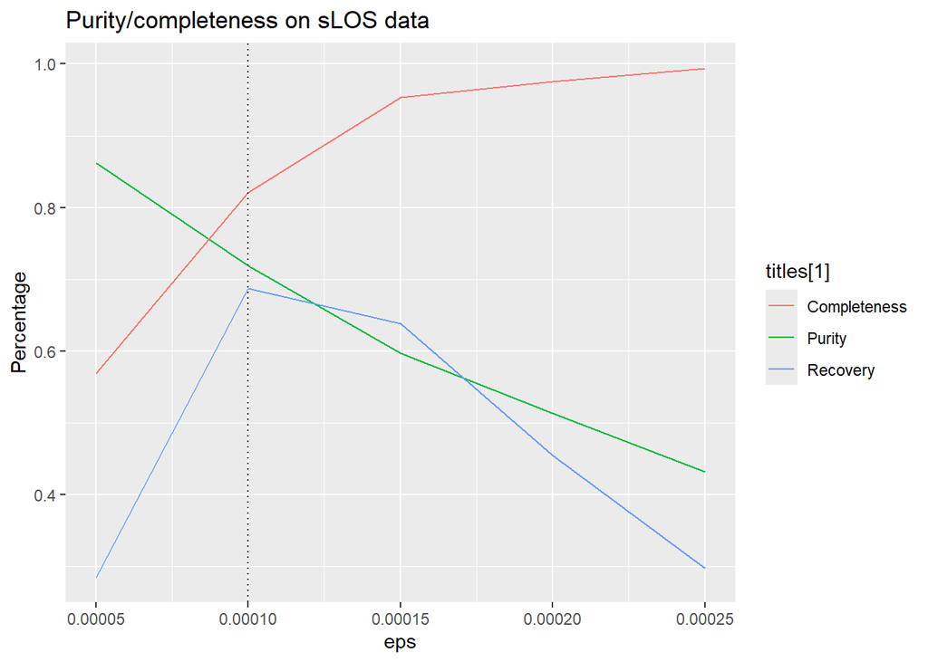

```r
seleced_eps <- 0.0001
plot_purity_completeness(
  eps_sequence_test,
  sx_stats$purity_list,
  sx_stats$completeness_list,
  sx_stats$recovery,
  c('Purity', 'Completeness', 'Recovery'),
  "Purity/completeness on sLOS data",
  seleced_eps, 'eps', 'Percentage'
)
```

There is a notable improvement of the results with the sLos distances.

Finally, for groups:

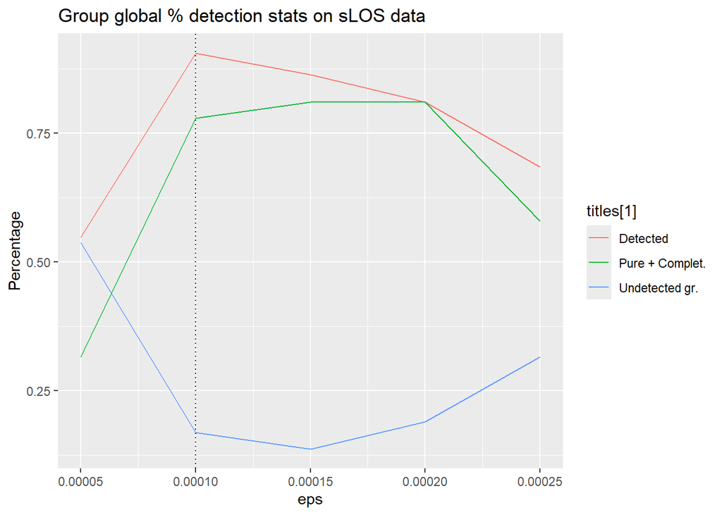

```r
plot_purity_completeness(
  eps_sequence_test,
  sx_stats$real_list/true_groups,
  sx_stats$und_gr/true_groups,
  sx_stats$pure_complet/true_groups,
  c('Detected', 'Undetected gr.', 'Pure + Complet.'),
  "Group global % detection stats on sLOS data",
  seleced_eps , 'eps', 'Percentage'
)
```

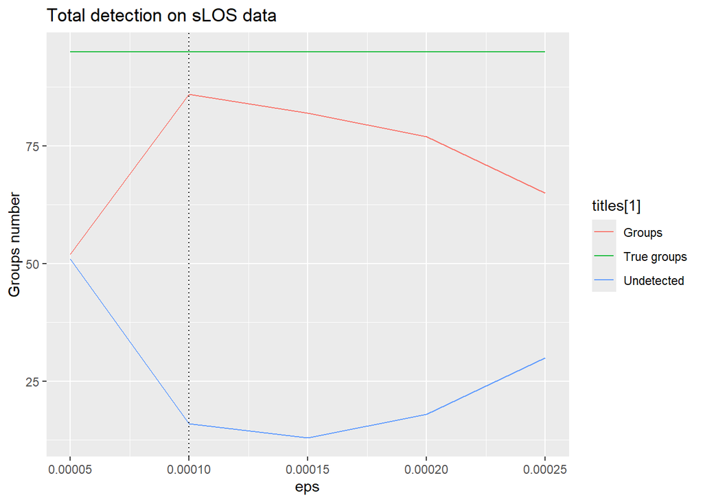

```r
plot_purity_completeness(
  eps_sequence_test,
  sx_stats$und_gr,
  sx_stats$real_list,
  true_groups - 0,
  c('Undetected', 'Groups', 'True groups'),
  "Total detection on sLOS data",
   seleced_eps , 'eps', 'Groups number'
)
```

Detected and undetected groups:

```r
sblo_scan <- extractDBSCAN(sres, eps_cl = seleced_eps)
mm$cluster_id <- sblo_scan$cluster

all <- execute_stats(mm, sblo_scan)

undetected <- get_elements_not_in_groups(mm5, all)
detected <- get_elements_in_groups(mm, all)

print(sprintf('Undetected groups: %s', length(unique(undetected$GROUP_ID))))
```

```
## [1] "Undetected groups: 16"
```

```r
print(sprintf('Detected groups: %s', length(unique(detected$GROUP_ID))))
```

```
## [1] "Detected groups: 137"
```

Plot detected groups

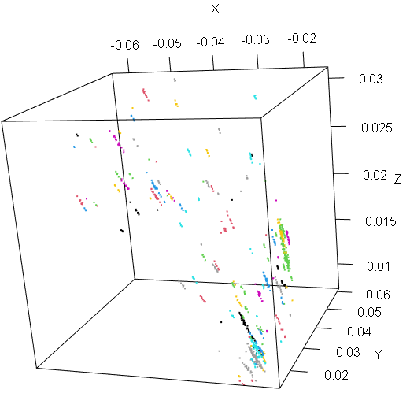

```r
plot3d(detected$x, detected$y, detected$z,
       col = detected$GROUP_ID +1, size = 2,
       xlab = "X", ylab = "Y", zlab = "Z")
```

Plot not detected groups

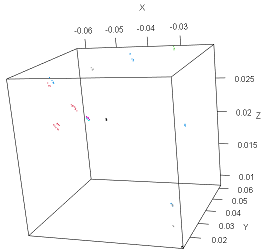

```r
plot3d(undetected$x, undetected$y, undetected$z,
       col = undetected$GROUP_ID +1, size = 2,
       xlab = "X", ylab = "Y", zlab = "Z")
```

# 10 Summary and conclusions

The bests results obtained with each method:

[output not shown]

# 11 Executive summary

Finally we compare the original with the best clustering obtained in this study:

Actual groups distribution

Best cluster detection with sOPTICS.

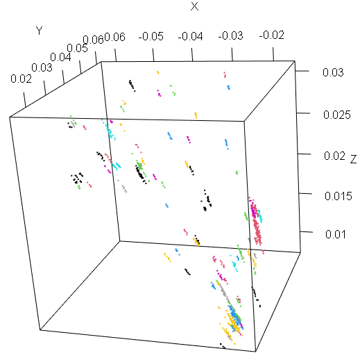

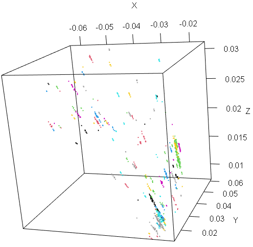